# A study of National Storm Data

### Synopsis

Based on the U.S. National Oceanic and Atmospheric Administration’s (NOAA) storm database, we find out the types of event which are most harmful for population health, and which cause greatest economic consequences.

### Data Processing

#### Read and Clean Data

This storm data records the storm event in US ranging from 1950 to November 2011. It can be downloaded from [here](https://d396qusza40orc.cloudfront.net/repdata%2Fdata%2FStormData.csv.bz2). Explanations of this data can be found in its [documentation](https://d396qusza40orc.cloudfront.net/repdata%2Fpeer2_doc%2Fpd01016005curr.pdf) and the [FAQ](https://d396qusza40orc.cloudfront.net/repdata%2Fpeer2_doc%2FNCDC%20Storm%20Events-FAQ%20Page.pdf).

It turns out the data file is quite large, reading in directly would take a large part of memory. Besides, we only need the columns which describes the population health and economic loss. Let’s check the column names in this data set:

```r
data_oneline = read.csv(bzfile("repdata-data-StormData.csv.bz2"),header=T,stringsAsFactors=F, nrow=1)
print(colnames(data_oneline))
```

```
##  [1] "STATE__"    "BGN_DATE"   "BGN_TIME"   "TIME_ZONE"  "COUNTY"
##  [6] "COUNTYNAME" "STATE"      "EVTYPE"     "BGN_RANGE"  "BGN_AZI"
## [11] "BGN_LOCATI" "END_DATE"   "END_TIME"   "COUNTY_END" "COUNTYENDN"
## [16] "END_RANGE"  "END_AZI"    "END_LOCATI" "LENGTH"     "WIDTH"
## [21] "F"          "MAG"        "FATALITIES" "INJURIES"   "PROPDMG"
## [26] "PROPDMGEXP" "CROPDMG"    "CROPDMGEXP" "WFO"        "STATEOFFIC"
## [31] "ZONENAMES"  "LATITUDE"   "LONGITUDE"  "LATITUDE_E" "LONGITUDE_"
## [36] "REMARKS"    "REFNUM"
```

According the documentation, only the following columns are what we need:  
1. `EVTYPE`: event type  
2. `FATALITIES`: count of fatalities  
3. `INJURIES`: count of injuries  
4. `PROPDMG`: amount of property damage  
5. `PROPDMGEXP`: exponent of property damage: k for 10^3, m for 10^6, b for 10^9  
6. `CROPDMG`: amount of crop damage  
7. `CROPDMGEXP`: exponent of crop damage: k for 10^3, m for 10^6, b for 10^9

Item 2, 3 are related to population health, while item 4~7 qualifies property damage. To address our problem, we only need to read in the above columns. This can be acheived by specifying `colClasses`.

```r
library(knitr) # for r markdown execution
library(data.table) # for easy data manipunation
colClassNeeded = c(rep("NULL", 7), "character",
                   rep("NULL", 14), "numeric", "numeric",
                   "numeric", "character",
                   "numeric", "character",
                   rep("NULL", 9))
stormData = read.csv(bzfile("repdata-data-StormData.csv.bz2"),
                     colClasses = colClassNeeded,
                     header=T, stringsAsFactors=F)
stormData_dt = data.table(stormData)
rm(stormData) # clean to save memory
```

This procedure also drops all NAs, replacing them by blank `""`. We also need to combine the number and the corresponding exponent for property damage and to clean the data.

```r
# take care of NAs and exponent for property damage
stormData_dt$PROPDMGEXP[stormData_dt$PROPDMGEXP == ""]  = 1
stormData_dt$PROPDMGEXP[stormData_dt$PROPDMGEXP == "K"] = 1e3
stormData_dt$PROPDMGEXP[stormData_dt$PROPDMGEXP == "M"] = 1e6
stormData_dt$PROPDMGEXP[stormData_dt$PROPDMGEXP == "B"] = 1e9
stormData_dt$PROPDMGEXP = suppressWarnings(as.numeric(stormData_dt$PROPDMGEXP))
# take care of NAs and exponent for crop damage
stormData_dt$CROPDMGEXP[stormData_dt$CROPDMGEXP == ""]  = 1
stormData_dt$CROPDMGEXP[stormData_dt$CROPDMGEXP == "K"] = 1e3
stormData_dt$CROPDMGEXP[stormData_dt$CROPDMGEXP == "M"] = 1e6
stormData_dt$CROPDMGEXP[stormData_dt$CROPDMGEXP == "B"] = 1e9
stormData_dt$CROPDMGEXP = suppressWarnings(as.numeric(stormData_dt$CROPDMGEXP))
```

#### Process Data

Now we start to process data. We realize that the population health is basically descibed by the total number of fatalities and injuries, so we sum these two up to create a new factor HEALTHLOSS; while the economic consequence is the sum of property damages and crop damage, we sum these two damages up to a new column ECONOMICLOSS

```r
stormData_dt$HEALTHLOSS   = stormData_dt$FATALITIES+stormData_dt$INJURIES
stormData_dt$ECONOMICLOSS = stormData_dt$PROPDMG*stormData_dt$PROPDMGEXP +
                          stormData_dt$CROPDMG*stormData_dt$CROPDMGEXP
```

Now we are entitled to give the results to the two questions.

### Results

#### Most harmful event for population health

We summarize the `HEALTHLOSS` data by event type do a bar plot to the top 10 events. Then we easily identify that **tornado** causes severest population health problem.

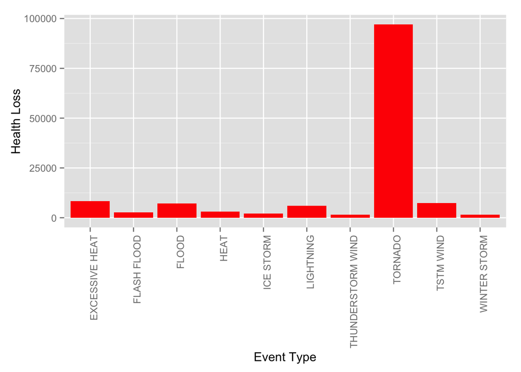

```r
healthRank = stormData_dt[, sum(HEALTHLOSS), by=EVTYPE]
healthRank = healthRank[order(-V1)]
healthRankTop10 = healthRank[1:10,]
library(ggplot2)
plot1 = ggplot(healthRankTop10, aes(x = EVTYPE, y=V1))
plot1 + geom_bar(stat="identity",fill="red") +
    xlab("Event Type") + ylab("Health Loss") +
    theme(axis.text.x = element_text(angle = 90, hjust = 1)) # rotate x labels to accomodate more characters
```

##### Event causes the greatest economic consequences

In a similar way, we summarise the `ECONOMICLOSS` data by event type, and do a bar plot to the top 10 events:

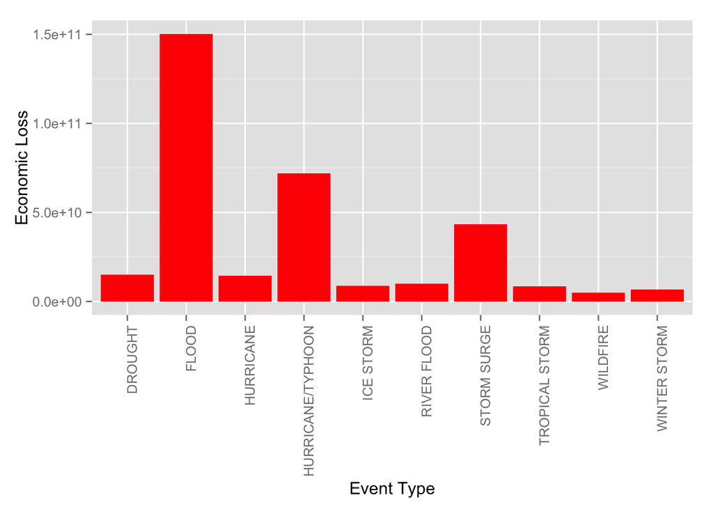

```r
economicRank = stormData_dt[, sum(ECONOMICLOSS), by=EVTYPE]
economicRank = economicRank[order(-V1)]
economicRankTop10 = economicRank[1:10,]
plot2 = ggplot(economicRankTop10, aes(x = EVTYPE, y=V1))
plot2 + geom_bar(stat="identity",fill="red") +
    xlab("Event Type") + ylab("Economic Loss") +
    theme(axis.text.x = element_text(angle = 90, hjust = 1)) # rotate x labels to accomodate more characters
```

Obvisously,**flood** is the event which brings the largest economic consequences.